# BSMM-lab-3

BSMM 8740 Fall 2023

Author

Rifah Tasfia Amin

Published

January 10, 2024

## Setup

Load packages and data:

```r
# install.packages("skimr") #
# install.packages("janitor") #
boston_cocktails <- readr::read_csv('data/boston_cocktails.csv')
```

## Exercises

### Exercise 1

```r
# Load the required libraries #
library(magrittr)   # the pipe
library(tidyverse)  # for data wrangling + visualization
library(tidymodels) # for modeling
library(gt) # for pretty tables


boston_cocktails <- readr::read_csv('data/boston_cocktails.csv') # Load the Boston Cocktail Recipes data set #
# Use skim to assess dataset quality
skimr::skim(boston_cocktails)
```

Data summary

| Name | boston_cocktails |
| --- | --- |
| Number of rows | 2542 |
| Number of columns | 7 |
| _______________________ |  |
| Column type frequency: |  |
| character | 4 |
| numeric | 3 |
| ________________________ |  |
| Group variables | None |

**Variable type: character**

| skim_variable | n_missing | complete_rate | min | max | empty | n_unique | whitespace |
| --- | --- | --- | --- | --- | --- | --- | --- |
| name | 0 | 1 | 4 | 36 | 0 | 937 | 0 |
| category | 0 | 1 | 3 | 21 | 0 | 11 | 0 |
| ingredient | 0 | 1 | 3 | 23 | 0 | 40 | 0 |
| measure | 0 | 1 | 1 | 8 | 0 | 28 | 0 |

**Variable type: numeric**

| skim_variable | n_missing | complete_rate | mean | sd | p0 | p25 | p50 | p75 | p100 | hist |
| --- | --- | --- | --- | --- | --- | --- | --- | --- | --- | --- |
| row_id | 0 | 1 | 495.37 | 284.75 | 1.00 | 261.25 | 497 | 730.75 | 990 | ▇▇▇▇▇ |
| ingredient_number | 0 | 1 | 2.54 | 1.29 | 1.00 | 1.00 | 2 | 3.00 | 6 | ▇▃▂▁▁ |
| measure_number | 0 | 1 | 0.98 | 0.72 | 0.02 | 0.50 | 1 | 1.50 | 16 | ▇▁▁▁▁ |

```r
# Use introduce to explore variables in the dataset
DataExplorer::introduce(boston_cocktails)
```

```
# A tibble: 1 × 9
   rows columns discrete_columns continuous_columns all_missing_columns
  <int>   <int>            <int>              <int>               <int>
1  2542       7                4                  3                   0
# ℹ 4 more variables: total_missing_values <int>, complete_rows <int>,
#   total_observations <int>, memory_usage <dbl>
```

```r
# Calculate the median measure number
median_measure_number <- median(boston_cocktails$measure_number)
print(median_measure_number)
```

```
[1] 1
```

The median measure amount across across all cocktails is 1.

### Exercise 2

```r
#load the libraries #

library(tidyverse)
library(janitor)
#Select the columns mentioned #
select_columns <- boston_cocktails |>
  select(name, category, ingredient, measure_number)

# Pivot the table to create columns for each ingredient and fill missing values with zero #
pivoted_table <- select_columns |>
  pivot_wider(names_from = ingredient, values_from = measure_number, values_fill = 0)

# Clean column names #
cleaned_table <- pivoted_table |>
  janitor::clean_names()


# Evaludate how much gin is in the cocktail called Leap Frog Highball
gin_in_leap_frog_highball <- cleaned_table |>
  filter(name == "Leap Frog Highball") |>
  select(gin)

print(gin_in_leap_frog_highball)
```

```
# A tibble: 1 × 1
    gin
  <dbl>
1     2
```

The **Leap Frog Highball** contains 2 of gin

### Exercise 3

```r
library(recipes)


boston_cocktails <- read.csv("data/boston_cocktails.csv", header = TRUE)
View(boston_cocktails)

# Create a recipe object using the loaded dataset
recipe_obj <- recipe(~ ., data = boston_cocktails) |>
  update_role(name, category, new_role = "id") |>
  step_dummy(all_nominal()) |>
  step_normalize(all_numeric()) |>
  step_pca(all_numeric(), num_comp = 3)

# Prepare the data
prepped_data <- prep(recipe_obj)

# Count the number of predictor variables prepped by the recipe
num_predictor_vars <- length(prepped_data$predictors)
print(num_predictor_vars)
```

```
[1] 0
```

0 predictor variables are prepped by the recipe.

### Exercise 4

```r
# Summarize the data to find the most used ingredient on average
ingredient_summary <- boston_cocktails |>
  group_by(ingredient) |>
  summarize(avg_measure_number = mean(measure_number, na.rm = TRUE)) |>
  arrange(desc(avg_measure_number))

most_used_ingredient <- ingredient_summary$ingredient[1]

print(most_used_ingredient ) # display the most used ingredient on an average #
```

```
[1] "cranberry juice"
```

On average the most used ingredient in the Boston Cocktails dataset is cranberry juice.

### Exercise 5

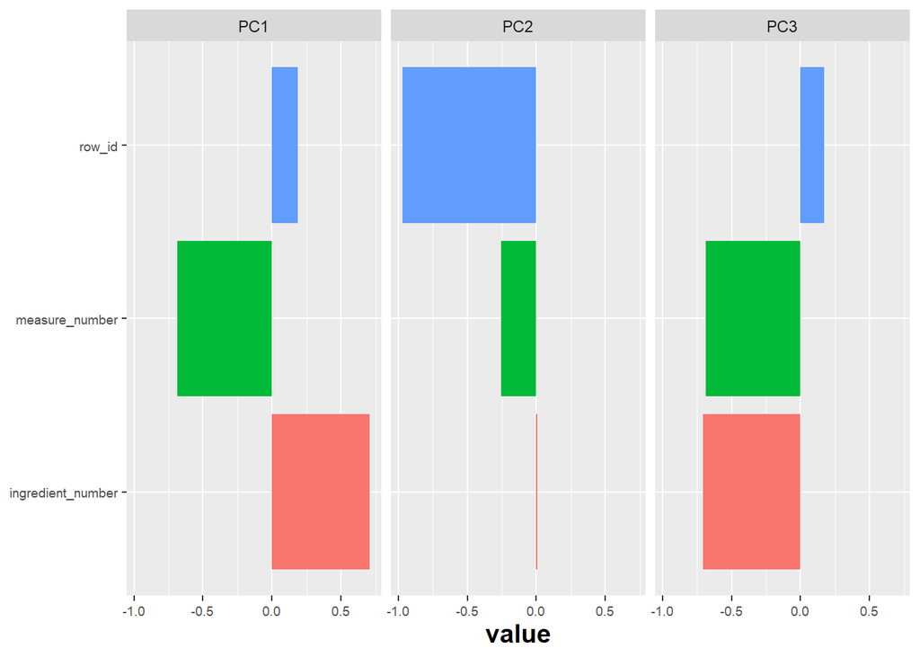

```r
library(recipes)
library(dplyr)
library(forcats)
library(ggplot2)

# Assuming 'boston_cocktails' is your dataset
numeric_columns <- select_if(boston_cocktails, is.numeric)

boston_cocktails_recipe <-
  recipe(~., data = numeric_columns) %>%
  update_role(., row_id, ingredient_number, measure_number) %>%
  step_naomit(all_predictors()) %>%
  step_normalize(all_predictors()) %>%
  step_pca(all_predictors(), id = "pca") %>%
  prep()

boston_cocktails_pca <-
  boston_cocktails_recipe %>%
  tidy(id = "pca", matrix = "X") # Use matrix = "X" to keep the original data matrix

# Filter for components PC1 to PC5 and mutate them as factors
boston_cocktails_pca_filtered <- boston_cocktails_pca %>%
  filter(component %in% c("PC1", "PC2", "PC3", "PC4", "PC5")) %>%
  mutate(component = fct_inorder(component))

# Create the PCA plot
ggplot(boston_cocktails_pca_filtered, aes(x = value, y = terms, fill = terms)) +
  geom_col(show.legend = FALSE) +
  facet_wrap(~component, nrow = 1) +
  labs(y = NULL) +
  theme(axis.text = element_text(size = 7),
        axis.title = element_text(size = 14, face = "bold"))
```

- If row_id is between 0 and 0.25 and has a positive loading in PC1, then when row_id is in this range, it contributes positively to higher values of PC1.
- If measure_number is between 0 and -0.7 and has a negative loading in PC1, then when measure_number is in this range, it contributes negatively to higher values of PC1.
- If ingredient_number is between 0 and 0.7 and has a positive loading in PC1, then when ingredient_number is in this range, it contributes positively to higher values of PC1.

### Exercise 6

```r
# Load required libraries
library(dplyr)
library(gt)

# Assuming 'boston_cocktails_pca_filtered' contains your PCA data
# Replace it with your actual data if necessary

# Create a function to color cells based on value
color_cells <- function(x) {
  ifelse(x < 0, "red", "green")
}

# Slice the top 8 ingredients by component based on absolute value
top_ingredients_table <- boston_cocktails_pca_filtered %>%
  filter(component %in% c("PC1", "PC2", "PC3", "PC4")) %>%
  group_by(component) %>%
  slice_max(order_by = abs(value), n = 8) %>%
  ungroup() %>%
  pivot_wider(names_from = component, values_from = terms)

# Modify the table to add cell background colors using gt
for (col in names(top_ingredients_table)[-1]) {
  top_ingredients_table[[col]] <- sapply(top_ingredients_table[[col]], function(x) {
    cell_style <- color_cells(x)
    sprintf('<span style="background-color: %s">%s</span>', cell_style, x)
  })
}

# Create the gt table
table_pca_ingredients <- top_ingredients_table %>%
  gt() %>%
  tab_style(
    style = cell_fill(
      color = color_cells(0)
    ),
    locations = cells_body()
  )

# Print the table
table_pca_ingredients
```

| value | id | PC1 | PC2 | PC3 |
| --- | --- | --- | --- | --- |
| 0.706232202 | <span style="background-color: green">pca</span> | <span style="background-color: green">ingredient_number</span> | <span style="background-color: NA">NA</span> | <span style="background-color: NA">NA</span> |
| -0.683258451 | <span style="background-color: green">pca</span> | <span style="background-color: green">measure_number</span> | <span style="background-color: NA">NA</span> | <span style="background-color: NA">NA</span> |
| 0.185456103 | <span style="background-color: green">pca</span> | <span style="background-color: green">row_id</span> | <span style="background-color: NA">NA</span> | <span style="background-color: NA">NA</span> |
| -0.967237404 | <span style="background-color: green">pca</span> | <span style="background-color: NA">NA</span> | <span style="background-color: green">row_id</span> | <span style="background-color: NA">NA</span> |
| -0.253730623 | <span style="background-color: green">pca</span> | <span style="background-color: NA">NA</span> | <span style="background-color: green">measure_number</span> | <span style="background-color: NA">NA</span> |
| 0.008519134 | <span style="background-color: green">pca</span> | <span style="background-color: NA">NA</span> | <span style="background-color: green">ingredient_number</span> | <span style="background-color: NA">NA</span> |
| -0.707929022 | <span style="background-color: green">pca</span> | <span style="background-color: NA">NA</span> | <span style="background-color: NA">NA</span> | <span style="background-color: green">ingredient_number</span> |
| -0.684674127 | <span style="background-color: green">pca</span> | <span style="background-color: NA">NA</span> | <span style="background-color: NA">NA</span> | <span style="background-color: green">measure_number</span> |
| 0.173371966 | <span style="background-color: green">pca</span> | <span style="background-color: NA">NA</span> | <span style="background-color: NA">NA</span> | <span style="background-color: green">row_id</span> |

### Exercise 7

```r
# Load required libraries
library(dplyr)
library(recipes)
library(ggplot2)


# Assuming 'boston_cocktails' is your data frame

# Create the PCA recipe
rec <- recipe(~., data = boston_cocktails)
pca_trans <- rec %>%
  step_normalize(all_numeric()) %>%
  step_pca(all_numeric(), num_comp = 3)
pca_estimates <- prep(pca_trans, training = boston_cocktails)
pca_data <- bake(pca_estimates, boston_cocktails)

# Extend the range for the plot
rng <- extendrange(c(pca_data$PC1, pca_data$PC2))


# Create PCA with threshold
with_thresh <- rec %>%
  step_normalize(all_numeric()) %>%
  step_pca(all_numeric(), threshold = 0.99)
with_thresh <- prep(with_thresh, training = boston_cocktails)
baked_with_thresh <- bake(with_thresh, boston_cocktails)

# Print tidy PCA results
tidy(pca_trans, number = 2)
```

```
# A tibble: 1 × 4
  terms         value component id
  <chr>         <dbl> <chr>     <chr>
1 all_numeric()    NA <NA>      pca_nafnb
```

```r
tidy(pca_estimates, number = 2)
```

```
# A tibble: 9 × 4
  terms                value component id
  <chr>                <dbl> <chr>     <chr>
1 row_id             0.185   PC1       pca_nafnb
2 ingredient_number  0.706   PC1       pca_nafnb
3 measure_number    -0.683   PC1       pca_nafnb
4 row_id            -0.967   PC2       pca_nafnb
5 ingredient_number  0.00852 PC2       pca_nafnb
6 measure_number    -0.254   PC2       pca_nafnb
7 row_id             0.173   PC3       pca_nafnb
8 ingredient_number -0.708   PC3       pca_nafnb
9 measure_number    -0.685   PC3       pca_nafnb
```

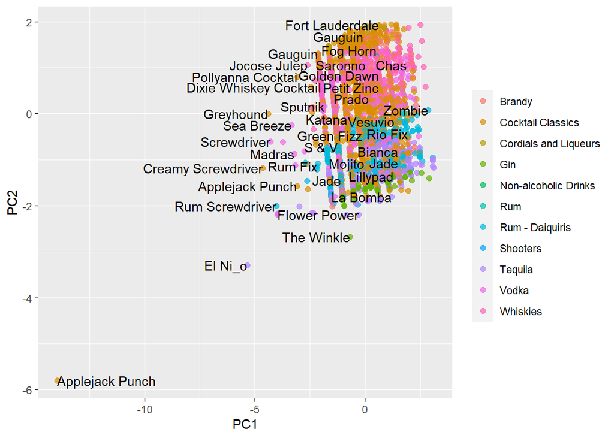

```r
# Create the scatter plot of PC1 and PC2 with labels
ggplot(pca_data, aes(PC1, PC2, label = name)) +
  geom_point(aes(color = category), alpha = 0.7, size = 2) +
  geom_text(check_overlap = TRUE, hjust = "inward") +
  labs(color = NULL)
```

In this PCA analysis, PC1 and PC2 fail to distinctly separate data points, suggesting a complex or low-variance structure in the dataset. Further exploration of higher-dimensional components may be needed to uncover hidden patterns.